# Labra - kyberuhkatieto ja data-analytiikka

Opiskelijan nimi: Eino Puttonen

Opiskelijanumero: AB7200

Nimeä palauttamasi tiedosto seuraavasti: labra_k24_sukunimi_etunimi.html

## Yleisiä ohjeita

- Labra palautetaan Moodleen HTML-muodossa, vastaavasti kuten harjoituksetkin. Ks. palautuksen deadline Moodlesta. Myöhästyneitä palautuksia ei oteta vastaan.
- Kiinnitä huomiota esitysmuotoon ja raportointiin. Tee kuvaajista ja kaavioista siistejä ja havainnollisia (onhan kuvaajalla otsikko, näkyväthän selitteet, onko akselit nimetty, jne.).
- Kerro myös sanallisesti (koodauksen ohella), mitä havaintoja olet datasta tehnyt ja mitä näistä voit päätellä. Tulkitse tekemiäsi kuvaajia ja selitä mitä näissä näkyy.
- Kuvaajien ja tulosteiden pitää näkyä palauttamassasi tiedostossa. Avaa palautuksesi selaimessa ja tarkista että tulosteet ja kuvaajat näkyvät. Mikäli tulosteet ja/tai kuvaajat eivät näy, tehtävistä ei saa täysiä pisteitä.
- Kommentoi koodi ja kerro miksi teet ja mitä teet. Selostamalla osoitat, että ymmärrät mitä olet tekemässä. Lyhyt ja ytimekäs kommentointi/selostus koodirivien väliin riittää.
- Labra vastaa koetta, joka on yksilötehtävä ja siitä tulee selviytyä itsenäisesti. Tehtävien pähkäily kaverin kanssa ei enää labran kohdalla ole sallittua. Vilppitapauksissa ja niiden epäilyissä toimitaan Jamkin eettisten periaatteiden mukaisesti. Tiedonhaku, kurssimateriaalien hyödyntäminen ja dokumentaatioiden lukeminen on toki OK.

## Käytettävästä datasta

Kansio https://student.labranet.jamk.fi/~ajota/Datasets/Labra/ sisältää Zeek-työkalulla kerättyjä conn-, http- ja dns-lokitietoja erään järjestelmän verkkoliikenteestä 30.6. - 2.7.2023. Jokaisen päivän conn-, http- ja dns-lokitiedot ovat erikseen omissa tiedostoissaan (tiedostot nimetty conn_log_vvvv-kk-pp.json, dns_log_vvvv_kk_pp.json ja http_log_vvvv_kk_pp.json). Lokitietojen lisäksi kansio sisältää myös muita tiedostoja, joita voit hyödyntää verkkoliikenteen analysoinnissa.

Lisätietoa Zeek-työkalusta ja tiedostojen sisältämästä datasta löydät Zeekin dokumentaatiosta https://docs.zeek.org/en/master/about.html.

Erityisesti https://docs.zeek.org/en/master/scripts/base/protocols/conn/main.zeek.html#type-Conn::Info, https://docs.zeek.org/en/master/scripts/base/protocols/dns/main.zeek.html#type-DNS::Info ja https://docs.zeek.org/en/master/scripts/base/protocols/http/main.zeek.html#type-HTTP::Info voivat olla hyödyksi.

## IoA - Indications of Attack - 3 p

Ota selvää alle otsikoiduista hyökkäystavoista ja kirjoita omin sanoin:

- mitä nämä ovat
- mitä työkaluja näissä saatetaan käyttää
- mitä tunnusmerkkejä ko. hyökkäyksistä kannattaa etsiä ja miten hyökkäyksen voi havaita lokidatasta.

Vastauksen ohjeellinen pituus: n. 70-200 sanaa / hyökkäystapa.

**Käytä vastauksessasi Jamkin raportointiohjeissa ohjeistettua viittaustapaa (tekstiviite + lähdeluettelo). Ilman lähdemerkintöjä ja -viittauksia vastaus on 0 pistettä.**

**DoS- ja DDoS-hyökkäys**

DenialofService (DoS) on hyökkäys, jonka tarkoituksena on sulkea laite tai verkko, tehdä se saavuttamattomaksi tarkoitetuille käyttäjille. DoS-hyökkäykset saavuttavat tämän ylikuormittamalla kohteen liikenteellä tai lähettämällä sille tietoa, joka aiheuttaa kaatumisen. Molemmissa tapauksissa DoS-hyökkäys estää oikeutettuja käyttäjiä käyttämästä palvelua tai resurssia. (What is a denial of service attack (DoS)? 2024). Siinä missä DoS hyökkäys tehdään yhdeltä koneelta, DDoS hyökkäys hyödyntää useampia koneita ja usein bottiverkkoja vahingollisen liikenteen lähettämiseen. (How to DDOS | DoS and DDoS attack tools 2024)

Tunnettuja hyökkäystapoja on mm. LOIC ja HOIC, jotka mahdollistavat TCP- ja UDP- protokollakerroksen hyökkäykset. Slowloris joka hyökkää lähettämällä pieniä määriä dataa useiden yhteyksien kautta, pyrkien pitämään portit auki mahdollisimman pitkään ja ylikuormittamaan palvelimen resursseja. R.U.D.Y, joka lähettää POST-pyyntöjä puutteellisilla otsikoilla, sitoen palvelimen resursseja. (How to DDOS | DoS and DDoS attack tools 2024)

Logitiedoista hyökkäykset voidaan havaita esimerkiksi havainnoimalla epätavallisen suuria liikennemääriä tietyistä osoitteista. (Ganesh 2019). Etsimällä http 503- virheitä, mitkä viittaavat palvelinten ylikuormitukseen. Liikenteen lisääntyminen tiettyinä rajattuina aikoina tai esimerkiksi tietyltä ip-alueelta. (Marsh 2016)

Lähdeluetelo: Ganesh J. 2019. Log Parser – Identifying attacks from IIS Logs. Microsoft. Viitattu 9.4.2024 https://techcommunity.microsoft.com/t5/iis-support-blog/log-parser-identifying-dos-attacks-from-iis-logs/ba-p/342496

How to DDOS | DoS and DDoS attack tools. 2024. Cloudflare. Viitattu 9.4.2024. https://www.cloudflare.com/learning/ddos/ddos-attack-tools/how-to-ddos/

Marsh J. 2016. How to Detect and Analyze DDoS Attacks Using Log Analysis. Solarwinds. Viitattu 9.4.2024. https://www.loggly.com/blog/how-to-detect-and-analyze-ddos-attacks-using-log-analysis/

What is a denial of service attack (DoS)?. 2024. paloalto networks. Viitattu 9.4.2024. https://www.paloaltonetworks.com/cyberpedia/what-is-a-denial-of-service-attack-dos

**DNS-tunnelointi**

DNS-tunnelointi on hyökkäysmuoto, jossa DNS-pyyntöjä ohjataan hyökkääjän palvelimelle. Tunnelointia voidaan käyttää kolmella tavalla, komennon ja hallinnan saavuttamiseen, datan keräämiseen tai toisen protokollan tunnelointiin sen läpi. DNS-tunnelit ovat tehokkaita, koska DNS-pyyntöjä harvoin estetään palomuureilla. (Nuojua ym. 2017). DNS- sisältää vain vähän dataa, joten komennot ja datan kerääminen tapahtuvat hitaasti. Sitä voi olla vaikea havaita normaalista liikenteestä, koska DNS- protokollasta jää aina paljon logitietoa. (DNS TUNNELING ATTACK 2024)

Hyökkäystapa. Hyökkääjällä on haittaohjelman sisältävä palvelin ja sille osoittava verkkotunnus. Hyökkääjä tartuttaa tietokoneen haittaohjelmalla. Tähän käytetään DNS-requesteja, koska ne saavat kulkea palomuurin läpi. Tartunnan saanut kone lähettää kyselyn DNS- palvelimelle, joka välittää pyyntöjä juuri- ja verkkotunnuspalvelimille. Välitin ohjaa kyselyn hyökkääjän palvelimelle, jossa tunnelointiohjelma sijaitsee. Näin saadaan muodostettua yhteys DNS-välityspalvelimen kautta. (What is DNS Tunneling? 2024)

Havaitseminen logeista. DNS-requestien määrä, jos tietystä osoitteesta tulee suuri määrä pyyntöjä päivässä etenkin UDP-protkollaa käyttäen, joka häviää helposti ”hälyyn”. DNS-requestien koko, domain-nimien requestit ovat yleensä lyhyitä base64:ssa, jos requestit ylittävät toistuvasti esim. 70 merkkiä, se on epätavallista ja voi auttaa havaitsemaan hyökkäyksen. Selvitetään ulos lähtevien DNS-pyyntöjen kohdeosoite, koska haittaohjelmat käyttävät yleensä ulkoisia DNS-palvelimia. (Detecting DNS Tunneling 2014) Lähdeluettelo:

Detecting DNS Tunneling. 2014. LogRythm. Viitattu 9.4.2024. https://logrhythm.com/blog/detecting-dns-tunneling/

DNS TUNNELING ATTACK: DEFINITION, EXAMPLES AND PREVENTION. 2024. EXTRAHOP. Viitattu 9.4.2024. https://hop.extrahop.com/resources/attacks/dns-tunneling/

Nuojua V, David G, Hämäläinen T. 2017. DNS Tunneling Detection Techiques – Classification and Theoretical Comparison in Case of a Real APT Campaign. JYU. ISBN. 978-3-319-67379-0

## Datan lukeminen, yhdistäminen ja esikäsittely - 2 p

### Datan lukeminen ja yhdistäminen

Yhdistä eri päivien (30.6.2023, 1.7.2023 ja 2.7.2023) conn-, http- ja dns-lokitiedostojen data omiin dataframeihinsa df_conn, df_dns ja df_http siten, että df_conn sisältää koko aikavälin yhteyslokitiedot, df_dns kaikki dns-lokitiedot ja df_http kaikki http-lokitiedot.

Voit itse valita, lataatko tiedostot omalle koneelle vai luetko datan urlin kautta.

```python
import pandas as pd
#tuodaan conn_logit
#conn_url1="https://student.labranet.jamk.fi/~ajota/Datasets/Labra/conn_log_2023-06-30.json"
#conn_url2="https://student.labranet.jamk.fi/~ajota/Datasets/Labra/conn_log_2023-07-01.json"
#conn_url3="https://student.labranet.jamk.fi/~ajota/Datasets/Labra/conn_log_2023-07-02.json"
conn1=pd.read_json("https://student.labranet.jamk.fi/~ajota/Datasets/Labra/conn_log_2023-06-30.json")
conn2=pd.read_json("https://student.labranet.jamk.fi/~ajota/Datasets/Labra/conn_log_2023-07-01.json")
conn3=pd.read_json("https://student.labranet.jamk.fi/~ajota/Datasets/Labra/conn_log_2023-07-02.json")
#yhdistetään dataframe,ja nollataan indexit
df_conn=pd.concat([conn1,conn2,conn3], ignore_index=True)
#df_conn
#Tehdään sama dns logeille
dns1=pd.read_json("https://student.labranet.jamk.fi/~ajota/Datasets/Labra/dns_log_2023-06-30.json")
dns2=pd.read_json("https://student.labranet.jamk.fi/~ajota/Datasets/Labra/dns_log_2023-07-01.json")
dns3=pd.read_json("https://student.labranet.jamk.fi/~ajota/Datasets/Labra/dns_log_2023-07-02.json")
df_dns=pd.concat([dns1,dns2,dns3], ignore_index=True)
#display(df_dns)
#ja httplle
http1=pd.read_json("https://student.labranet.jamk.fi/~ajota/Datasets/Labra/http_log_2023-06-30.json")
http2=pd.read_json("https://student.labranet.jamk.fi/~ajota/Datasets/Labra/http_log_2023-07-01.json")
http3=pd.read_json("https://student.labranet.jamk.fi/~ajota/Datasets/Labra/http_log_2023-07-02.json")
df_http=pd.concat([http1,http2,http3], ignore_index=True)
#df_http
```

### Aikaleimat

Conn-, http- ja dns-lokitiedoissa aikaleimat ovat unix-ajassa (UTC).

- Tee kuhunkin dataframeen uusi "Timestamp"-sarake, johon unix-aika sarakkeesta 'ts' on muutettu UTC+2 -aikaan.
- Järjestä sarakkeet uudelleen siten, että Timestamp-sarake on ensimmäisenä.
- Tiputa pois 'ts'-sarake.

Tulosta lopuksi kustakin dataframesta 3 ensimmäistä riviä ja sarkkeiden lukumäärä näkyviin.

```python
# Aikaleimat
#df_conn, tehdään Timestamp sarake ja muutetaan se ts sarakkeesta UTC+2 aikaan, UTC alkuperäisaika ja convertoinnilla UTC+2 aikaan
#luettavuuden takia muutetaan aikalema stringiksi
df_conn['Timestamp'] = pd.to_datetime(df_conn['ts'], unit='s').dt.tz_localize('UTC').dt.tz_convert('Europe/Helsinki').dt.strftime('%Y-%m-%d %H:%M:%S.%f').str.slice(stop=-4)
#siirretään Timestamp ensimmäiseksi irrottamalla se popilla ja liittämällä ensimmäiseen indeksiin
moveTS=df_conn.pop("Timestamp")
df_conn.insert(0, "Timestamp", moveTS)
#poistetaan ts sarake
df_conn.drop(columns=['ts'], inplace=True)
#järjestetään aikaleimojen mukaan
df_conn= df_conn.sort_values(by='Timestamp')
#uudelleen indeksoidaan dataframe
df_conn=df_conn.reset_index(drop=True)
#tulostetaan kolme ensimmäistä riviä
display(df_conn.head(3))
#shape laskee rivien ja sarkkaiden määrän, indeksill [1] voidaan kutsua sarakkeiden määrä
col_conn=df_conn.shape[1]
print('Sarakkaiden määrä df_conn dataframessa, ', col_conn)

#tehdään sama myös http- ja dns- logeille
df_http['Timestamp'] = pd.to_datetime(df_http['ts'], unit='s').dt.tz_localize('UTC').dt.tz_convert('Europe/Helsinki').dt.strftime('%Y-%m-%d %H:%M:%S.%f').str.slice(stop=-4)
moveTShttp=df_http.pop('Timestamp')
df_http.insert(0, 'Timestamp', moveTShttp)
df_http.drop(columns=['ts'], inplace=True)
display(df_http.head(3))
col_http=df_http.shape[1]
print('Sarakkaiden määrä df_http dataframessa, ', col_http)

df_dns
df_dns['Timestamp'] = pd.to_datetime(df_dns['ts'], unit='s').dt.tz_localize('UTC').dt.tz_convert('Europe/Helsinki').dt.strftime('%Y-%m-%d %H:%M:%S.%f').str.slice(stop=-4)
moveTSdns=df_dns.pop('Timestamp')
df_dns.insert(0, 'Timestamp', moveTSdns)
df_dns.drop(columns=['ts'], inplace=True)
display(df_dns.head(3))
col_dns=df_dns.shape[1]
print('Sarakkaiden määrä df_dns dataframessa, ', col_dns)
```

|  | Timestamp | uid | id.orig_h | id.orig_p | id.resp_h | id.resp_p | proto | service | duration | orig_bytes | resp_bytes | conn_state | local_orig | local_resp | missed_bytes | history | orig_pkts | orig_ip_bytes | resp_pkts | resp_ip_bytes |
| --- | --- | --- | --- | --- | --- | --- | --- | --- | --- | --- | --- | --- | --- | --- | --- | --- | --- | --- | --- | --- |
| 0 | 2023-06-30 23:56:05.64 | Cv2Yo7IpKK2XOxfI8 | 10.40.20.99 | 38830 | 10.40.20.84 | 9200 | tcp | None | 467.773876 | 30605.0 | 21358.0 | SHR | True | True | 0 | CadCDcf | 1 | 13084 | 69 | 19154 |
| 1 | 2023-06-30 23:57:08.96 | C10Moa3GKKEOwb0Da3 | 10.40.20.110 | 64862 | 10.40.20.99 | 8080 | tcp | None | 0.000482 | 0.0 | 0.0 | OTH | True | True | 0 | ^cA | 1 | 40 | 0 | 0 |
| 2 | 2023-06-30 23:59:44.83 | C0rkEy2gXPMjtpwnci | fe80::ffff:ffff:ffff:ffff | 130 | ff02::1 | 131 | icmp | None | NaN | NaN | NaN | OTH | False | False | 0 | None | 1 | 76 | 0 | 0 |

```
Sarakkaiden määrä df_conn dataframessa,  20
```

|  | Timestamp | uid | id.orig_h | id.orig_p | id.resp_h | id.resp_p | trans_depth | method | host | uri | user_agent | request_body_len | response_body_len | tags | proxied | origin | orig_fuids | orig_mime_types | version | status_code | status_msg | resp_fuids | resp_filenames | resp_mime_types |
| --- | --- | --- | --- | --- | --- | --- | --- | --- | --- | --- | --- | --- | --- | --- | --- | --- | --- | --- | --- | --- | --- | --- | --- | --- |
| 0 | 2023-07-01 00:04:09.73 | CwpM8q3xxbvfvbcRh2 | 10.40.20.100 | 57374 | 10.40.20.99 | 80 | 1 | GET | 10.40.20.99 | / | Mozilla/5.0 (Windows NT 10.0; Win64; x64) Appl... | 0 | 0 | [] | None | None | None | None | NaN | NaN | NaN | NaN | NaN | NaN |
| 1 | 2023-07-01 00:06:16.29 | Cj2Cz41DbiTz22Co12 | 10.40.20.10 | 56368 | 10.40.20.99 | 8080 | 2 | GET | 10.40.20.99:8080 | /login.php | Mozilla/5.0 (Windows NT 10.0; Win64; x64) Appl... | 0 | 0 | [] | None | None | None | None | NaN | NaN | NaN | NaN | NaN | NaN |
| 2 | 2023-07-01 00:06:16.29 | Cj2Cz41DbiTz22Co12 | 10.40.20.10 | 56368 | 10.40.20.99 | 8080 | 1 | GET | 10.40.20.99:8080 | / | Mozilla/5.0 (Windows NT 10.0; Win64; x64) Appl... | 0 | 0 | [] | None | None | None | None | NaN | NaN | NaN | NaN | NaN | NaN |

```
Sarakkaiden määrä df_http dataframessa,  24
```

|  | Timestamp | uid | id.orig_h | id.orig_p | id.resp_h | id.resp_p | proto | trans_id | rcode | rcode_name | AA | TC | RD | RA | Z | rejected | query | answers | TTLs | qclass | qclass_name | qtype | qtype_name | rtt |
| --- | --- | --- | --- | --- | --- | --- | --- | --- | --- | --- | --- | --- | --- | --- | --- | --- | --- | --- | --- | --- | --- | --- | --- | --- |
| 0 | 2023-07-01 00:00:00.36 | CvbmIm2GtAVe7CpCw6 | 10.40.20.99 | 39472 | 10.40.20.10 | 53 | udp | 35275 | 3.0 | NXDOMAIN | False | False | False | False | 0 | False | None | None | None | NaN | None | NaN | None | NaN |
| 1 | 2023-07-01 00:00:00.36 | CvbmIm2GtAVe7CpCw6 | 10.40.20.99 | 39472 | 10.40.20.10 | 53 | udp | 35275 | 3.0 | NXDOMAIN | False | False | False | False | 0 | False | None | None | None | NaN | None | NaN | None | NaN |
| 2 | 2023-07-01 00:00:00.37 | CehCtm1jcCO3fW46K4 | 10.40.20.99 | 45543 | 10.40.20.10 | 53 | udp | 7832 | 0.0 | NOERROR | True | False | False | True | 0 | False | 10.20.40.10.in-addr.arpa | [dc.rt.vle.fi] | [1200.0] | NaN | None | NaN | None | NaN |

```
Sarakkaiden määrä df_dns dataframessa,  24
```

## Verkkoliikenteen määrän visualisointi - 2 p

Mikäli et saanut yhdistettyä ja esikäsiteltyä dataa, voit lukea yhdistetyt conn, dns ja http -lokitiedot visualisoitaviksi Labra-kansiosta. https://student.labranet.jamk.fi/~ajota/Datasets/Labra/conn_log_with_timestamps_30-06-2023_02-07-2023.json, https://student.labranet.jamk.fi/~ajota/Datasets/Labra/dns_log_with_timestamps_30-06-2023_02-07-2023.json ja https://student.labranet.jamk.fi/~ajota/Datasets/Labra/http_log_with_timestamps_30-06-2023_02-07-2023.json.

Visualisoi verkkoliikenteen määrä eri lokitiedostoista (conn, http ja dns) allekkaisiin kuvaajiin (subplots). Voit ensin kokeilla/hahmotella järkevää uudelleennäytteistysväliä (1 s, 5 s, 10 s, 15 s, ...), jolla saat aikavälin tapahtumat esitettyä tasaisin väliajoin.

- Aseta x-akselin välistys siten, että kuvaajista voi lukea tapahtumat vähintäänkin tunnin tarkkuudella.
- Aseta kuvaajiin labelit ja yhteinen otsikko.
- Aseta jokaiselle lokitiedolle eri väri.
- Aseta kuvaajiin vertikaalinen (pystysuuntainen) grid.

```python
#df_conn_log= pd.read_json('https://student.labranet.jamk.fi/~ajota/Datasets/Labra/http_log_with_timestamps_30-06-2023_02-07-2023.json')
#df_conn_log
```

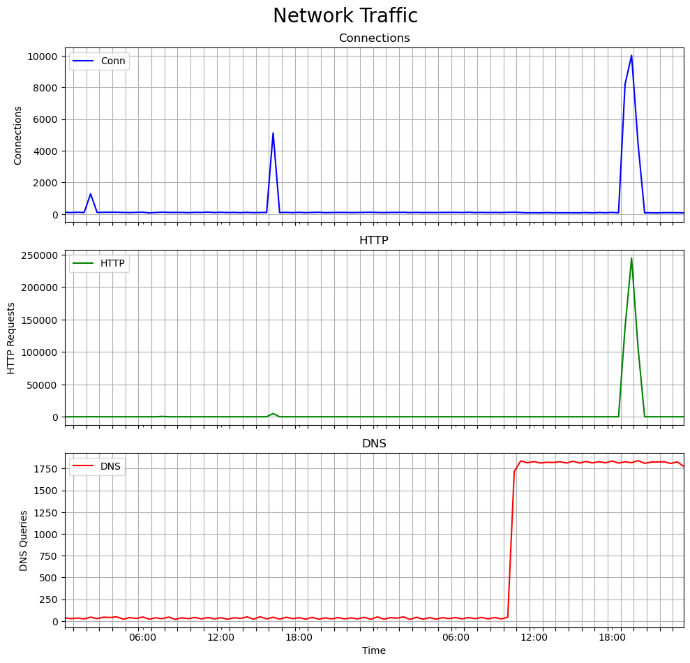

```python
# Verkkoliikenteen määrän visualisointi
#tuodaan matplotlib visualisointityökaluksi
import matplotlib.pyplot as plt
#uudelleennäytteistysväli testaamalla
#pakko muuttaa aikaleimat takaisin, koska muuten resample ei toimi
df_conn['Timestamp'] = pd.to_datetime(df_conn['Timestamp'])
df_http['Timestamp'] = pd.to_datetime(df_http['Timestamp'])
df_dns['Timestamp'] = pd.to_datetime(df_dns['Timestamp'])
interval='30T'

# liikennemäärä df_conn framessa, resample laskee annetuin aikavälein liikenteen määrää
conn_traffic= df_conn.set_index('Timestamp').resample(interval).size()
http_traffic=df_http.set_index('Timestamp').resample(interval).size()
dns_traffic=df_dns.set_index('Timestamp').resample(interval).size()

#tehdään kolme subplotia, 3 riville
#valittiin kolme erillistä kuvaajaa, koska eri kuvaajien osumamäärät ovat erikokoisia eivätkä ne skaalautneet järekvästi yhteen taulukkoon
fig, axes=plt.subplots(3,1, figsize=(10,10), sharex=True)
#conn_traffic
conn_traffic.plot(ax=axes[0], color='blue', grid=True)
#y-akselin otsikko
axes[0].set_ylabel('Connections')
#taulukon otsikko
axes[0].set_title('Connections')
#legend, joka näyttää mitä viivan väri tarkoittaa
axes[0].legend(['Conn'])
#aikaotsikko x-akselille
axes[0].set_xlabel('Time')
#http_traffic
http_traffic.plot(ax=axes[1], color='green', grid=True)
axes[1].set_ylabel('HTTP Requests')
axes[1].set_title('HTTP')
axes[1].legend(['HTTP'])
axes[1].set_xlabel('Time')
#dns_traffic
dns_traffic.plot(ax=axes[2], color='red', grid=True)
axes[2].set_ylabel('DNS Queries')
axes[2].set_title('DNS')
axes[2].legend(['DNS'])
axes[2].set_xlabel('Time')
#x- askelin ostikko
axes[-1].set_xlabel('Time')
#annetaan kuvaajille yhteinen otsikko
fig.suptitle('Network Traffic', fontsize=20)
#- kuvaajan otsikko
plt.tight_layout()
#lisätään xticit tunnin välein

plt.gca().xaxis.set_major_locator(plt.MaxNLocator(48))
plt.show()
```

## IP-osoitteiden visualisointi - 4 p

Tutki visualisoimalla lokidatassa esiintyviä IP-osoitteita lokitiedostoittain. Pyri muun muassa selvittämään

- Mihin IP-osoitteisiin liikenne kohdistuu (liikenteen määrä)?
- Tuleeko liikennettä jostakin tietystä IP-osoitteesta enemmän kuin muista?

Kiinnitä huomiota valitsemiesi kuvaajien tarkoituksenmukaisuuteen, havainnollisuuteen ja tietojen luettavuuteen. Voit visualisoida myös muita IP-osoitteisiin liittyviä tietoja, joita katsot tarpeelliseksi. Tulkitse tekemiäsi kuvaajia.

```python
#id.orig_h
#id.resp_h
#https://docs.zeek.org/en/master/logs/conn.html, mukaan id_orig_h on sourceIP ja id.resp_h DestinationIP
#eli vastataksemme kysymykseen mihin IP-osoitteisiin liikenne kohdistuu selvitetään id.resp_h määriä.
#lasketaan id.resp_h määrät eri osoitteista.
conn_dest_ip = df_conn.groupby('id.resp_h').size().reset_index(name='Counts')
#display(conn_dest_ip)
http_dest_ip =df_http.groupby('id.resp_h').size().reset_index(name='Counts')
#display(http_source_ip)
dns_dest_ip=df_dns.groupby('id.resp_h').size().reset_index(name='Counts')
#display(dns_dest_ip)
conn_source_ip=df_conn.groupby('id.orig_h').size().reset_index(name='Counts')
#display(conn_source_ip)
```

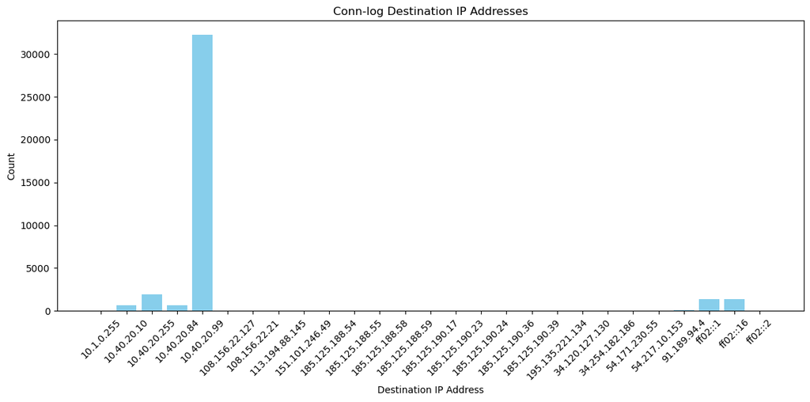

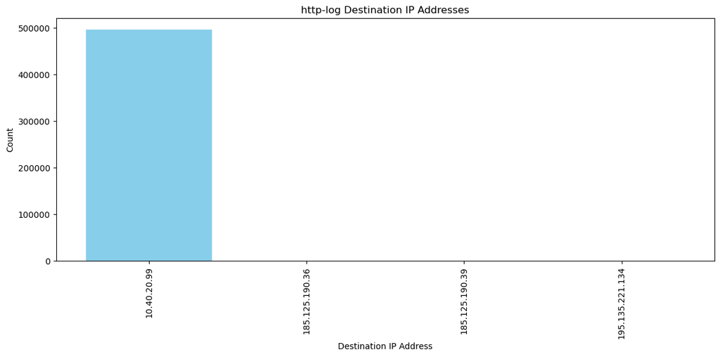

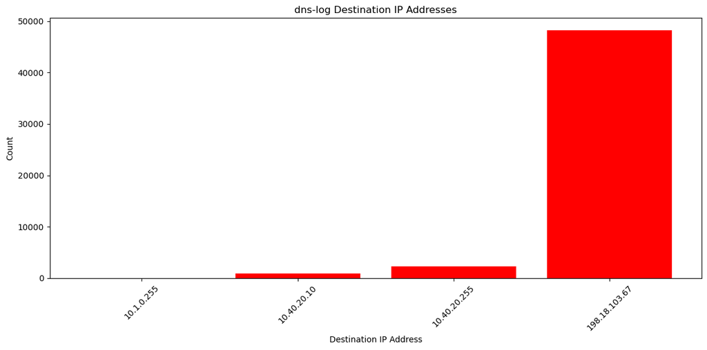

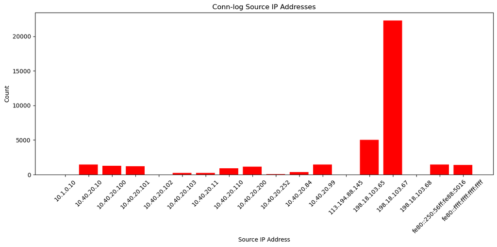

```python
# Kuvaaja conn-log-destination
plt.figure(figsize=(12, 6))
plt.bar(conn_dest_ip['id.resp_h'], conn_dest_ip['Counts'], color='skyblue')
plt.title('Conn-log Destination IP Addresses')
plt.xlabel('Destination IP Address')
plt.ylabel('Count')
plt.xticks(rotation=45)
plt.tight_layout()
plt.show()

# Kuvaja http-log-destination
plt.figure(figsize=(12, 6))
plt.bar(http_dest_ip['id.resp_h'], http_dest_ip['Counts'], color='skyblue')
plt.title('http-log Destination IP Addresses')
plt.xlabel('Destination IP Address')
plt.ylabel('Count')
plt.xticks(rotation=90)
plt.tight_layout()
plt.show()

# Kuvaaja dns-log-destination
plt.figure(figsize=(12, 6))
plt.bar(dns_dest_ip['id.resp_h'], dns_dest_ip['Counts'], color='red')
plt.title('dns-log Destination IP Addresses')
plt.xlabel('Destination IP Address')
plt.ylabel('Count')
plt.xticks(rotation=45)
plt.tight_layout()
plt.show()

# Kuvaaja conn-log-source
plt.figure(figsize=(12, 6))
plt.bar(conn_source_ip['id.orig_h'], conn_source_ip['Counts'], color='red')
plt.title('Conn-log Source IP Addresses')
plt.xlabel('Source IP Address')
plt.ylabel('Count')
plt.xticks(rotation=45)
plt.tight_layout()
plt.show()
```

## Kuvaajien selitykset IP- osoitteiden visualisointiin

Laskin ensin kustakin IP-osoitteesta tulevan liikenteen määrän. Näistä päädyin tekemään pylväskaaviot, koska niistä on visuaalisesti helppo havaita, jos yksittäinen pylväs eroaa selvästi muista. id.resp_h ymmäretään zeekissä Destiantion IPnä, joten näitä lähdin laskemaan.

dns-logissa esille nousi osoite 198.18.103.67, sama ip-nousi esille myös, laskettaessa tulevien yhteyksien määriä. Eli tämä tulos kuvasi dns-palvelimen keskustelua alkuperäisen lähettäjän kanssa.

Voidaan siis päätellä että osoitteesta 198.18.103.67 on pyritty ottamaan toistuvasti yhteyttä osoitteisiin 10.40.20.84 ja 10.40.20.99

## Datan suodattaminen - 6 p

Tutki lokitiedostojen dataa (esim.) suodattamalla, parsettamalla, tarkastelemalla sarakkeiden tietoja ja koostamalla tietoja.

Voit lähteä liikkeelle edellisten kohtien kuvaajissa näkyvistä tapahtumista ja näistä tehdyistä havainnoista.

- Saatko selville mitä kuvaajassa näkyvät tapahtumat ovat tai mitä näissä tapahtuu?
- Mitä muuta saat selville suodattamalla, parsettamalla ja koostamalla tietoja?

**Kommentoi koodiin mitä olet etsimässä/tekemässä ja miksi. Kiinnitä huomiota tulosteiden ja koosteiden selkeyteen. Tulosteiden lisäksi kerro havaintosi ja johtopäätöksesi sanallisesti Yhteenveto-kohdassa.**

### DNS-lokitietojen suodatus

```python
# DNS-lokitiedot
df_geoip=pd.read_csv('https://student.labranet.jamk.fi/~ajota/Datasets/Labra/geoip2-ipv4_csv.csv')
df_geoip
count_geoip=df_geoip.groupby('network').size().reset_index(name='Counts')
#display(count_geoip)
#pd.set_option('display.max_columns', None)
#display(df_dns)
```

## mitä tehdään

Aiemmissa kuvaajissa korostui ip:n 10.40.20.99 osuus kaikesta liikenteestä. Lähdetään selvittämään tarkemmin tätä liikennettä.

```python
compromised_ip= '10.40.20.99'
compromised_df=df_dns[df_dns['id.orig_h'] == (compromised_ip)]
#display(compromised_df)
#display(compromised_df.head(100))

#mihinkä portteihin liikennettä on mennyt
port_counts = df_dns['id.orig_p'].value_counts()
display(port_counts)

#logidatasta huomataan että, id.orig_p 45543 rivillä. On poikkeava vastaus query, answer ja TTL-sarakkeissa.
#tarkistetaan onko vastaavia yhteyksiä ollut useampaa
port_45543 = port_counts.get(45543,0)
print('To port 45543', port_45543)
#ei ole
#alkuperäisestä osoitteesta tullut kysely on saanut vastauksena dc.rt.vle.fi palvelimen osoitteen. Tietue on pysynyt auki 20 minuuttia(1200 sekuntia)
#pd.set_option('display.max_rows', None)
#display(compromised_df.head(200)). TÄSSÄ vaiheessa huomattiin queryissa ja answereissa vaihteluita, mutta tulosteesta on jätetty rivejä pois luettavuuden takia
display(compromised_df)
```

```
34895    48209
137       2256
35064        4
46596        3
52891        3
         ...
38476        1
44269        1
35886        1
46422        1
33864        1
Name: id.orig_p, Length: 623, dtype: int64
```

```
To port 45543 1
```

|  | Timestamp | uid | id.orig_h | id.orig_p | id.resp_h | id.resp_p | proto | trans_id | rcode | rcode_name | AA | TC | RD | RA | Z | rejected | query | answers | TTLs | qclass | qclass_name | qtype | qtype_name | rtt |
| --- | --- | --- | --- | --- | --- | --- | --- | --- | --- | --- | --- | --- | --- | --- | --- | --- | --- | --- | --- | --- | --- | --- | --- | --- |
| 0 | 2023-07-01 00:00:00.360 | CvbmIm2GtAVe7CpCw6 | 10.40.20.99 | 39472 | 10.40.20.10 | 53 | udp | 35275 | 3.0 | NXDOMAIN | False | False | False | False | 0 | False | None | None | None | NaN | None | NaN | None | NaN |
| 1 | 2023-07-01 00:00:00.360 | CvbmIm2GtAVe7CpCw6 | 10.40.20.99 | 39472 | 10.40.20.10 | 53 | udp | 35275 | 3.0 | NXDOMAIN | False | False | False | False | 0 | False | None | None | None | NaN | None | NaN | None | NaN |
| 2 | 2023-07-01 00:00:00.370 | CehCtm1jcCO3fW46K4 | 10.40.20.99 | 45543 | 10.40.20.10 | 53 | udp | 7832 | 0.0 | NOERROR | True | False | False | True | 0 | False | 10.20.40.10.in-addr.arpa | [dc.rt.vle.fi] | [1200.0] | NaN | None | NaN | None | NaN |
| 3 | 2023-07-01 00:00:00.380 | CXP4Eo1jB9UHLu1WE3 | 10.40.20.99 | 57353 | 10.40.20.10 | 53 | udp | 19228 | 3.0 | NXDOMAIN | False | False | False | False | 0 | False | None | None | None | NaN | None | NaN | None | NaN |
| 4 | 2023-07-01 00:00:00.380 | CXP4Eo1jB9UHLu1WE3 | 10.40.20.99 | 57353 | 10.40.20.10 | 53 | udp | 19228 | 3.0 | NXDOMAIN | False | False | False | False | 0 | False | None | None | None | NaN | None | NaN | None | NaN |
| ... | ... | ... | ... | ... | ... | ... | ... | ... | ... | ... | ... | ... | ... | ... | ... | ... | ... | ... | ... | ... | ... | ... | ... | ... |
| 51325 | 2023-07-02 23:58:42.590 | CrSgJVnN2eC7PYyj8 | 10.40.20.99 | 34895 | 198.18.103.67 | 53 | udp | 41865 | 0.0 | NOERROR | False | False | False | True | 0 | False | dnscat.13cc01b2fbfdc6697d0954bc3284eab341 | [TXT 34 df2a01b2fb7077cda2e7d8ffffba4e1246] | [60.0] | NaN | None | NaN | None | NaN |
| 51326 | 2023-07-02 23:58:50.630 | CrSgJVnN2eC7PYyj8 | 10.40.20.99 | 34895 | 198.18.103.67 | 53 | udp | 32052 | 0.0 | NOERROR | False | False | False | True | 0 | False | dnscat.f98201b2fbb0591ae51ac2bc3a2ddb619e | [TXT 34 bb8a01b2fb1de6858191cbffffba4e1246] | [60.0] | NaN | None | NaN | None | NaN |
| 51327 | 2023-07-02 23:59:01.680 | CrSgJVnN2eC7PYyj8 | 10.40.20.99 | 34895 | 198.18.103.67 | 53 | udp | 23353 | 0.0 | NOERROR | False | False | False | True | 0 | False | dnscat.1f8001b2fbffb783993232bc45c7d55544 | [dnscat.b6e201b2fb5fd58e60531effffba4e1246] | [60.0] | NaN | None | NaN | None | NaN |
| 51328 | 2023-07-02 23:59:04.690 | CrSgJVnN2eC7PYyj8 | 10.40.20.99 | 34895 | 198.18.103.67 | 53 | udp | 35344 | 0.0 | NOERROR | False | False | False | True | 0 | False | dnscat.89c501b2fb28c77cd05bcebc485d9931af | [dnscat.635901b2fbd71029a69f7affffba4e1246] | [60.0] | NaN | None | NaN | None | NaN |
| 51329 | 2023-07-02 23:58:58.660 | CrSgJVnN2eC7PYyj8 | 10.40.20.99 | 34895 | 198.18.103.67 | 53 | udp | 15559 | 0.0 | NOERROR | False | False | False | True | 0 | False | dnscat.c2ff01b2fb74de094ac8d1bc424bb1a1b4 | [dnscat.489e01b2fb559b3d8451cdffffba4e1246] | [60.0] | NaN | None | NaN | None | NaN |

49074 rows × 24 columns

```python
#tarkastellaan query, answer ja TTL sarakkeita tarkemmin
df_dns_susp= df_dns[['Timestamp','query','answers','TTLs']]
#pudotetaan kaikki None arvot answers- sarakkkeesta, jotta saadaan vain tarvittavaa tietoa luettavaksi.
df_dns_susp.dropna(subset=['answers'],inplace=True)
#pd.set_option('display.max_rows', None)
#Framen yläosa näytetään 50 riviä pitänä,jotta queryita ja answereita pystytään vertailemaan kunnolla.
display(df_dns_susp.head(50))
#Framen loppupäässä tunnelointi lähettää tekstimuotoista tietoa ulos.
display(df_dns_susp.tail(5))


#katsotaan mitkä koneet ovat vastanneet kyselyihin
#answers_count=df_dns_susp['answers'].value_counts() - Tätä ei voinut käyttää, koska erilaisia vastauksia oli niin paljon ettei kernel jaksanut pyörittää niitä läpi.
#print(answers_count)
```

|  | Timestamp | query | answers | TTLs |
| --- | --- | --- | --- | --- |
| 2 | 2023-07-01 00:00:00.370 | 10.20.40.10.in-addr.arpa | [dc.rt.vle.fi] | [1200.0] |
| 7 | 2023-07-01 00:00:00.430 | 100.20.40.10.in-addr.arpa | [w10-1.rt.vle.fi] | [1200.0] |
| 10 | 2023-07-01 00:00:00.440 | 101.20.40.10.in-addr.arpa | [w10-2.rt.vle.fi] | [1200.0] |
| 11 | 2023-07-01 00:00:00.450 | 110.20.40.10.in-addr.arpa | [w11-1.rt.vle.fi] | [3600.0] |
| 12 | 2023-07-01 00:00:00.740 | 55.188.125.185.in-addr.arpa | [api.snapcraft.io] | [3600.0] |
| 13 | 2023-07-01 00:00:00.750 | 4.94.189.91.in-addr.arpa | [pugot.canonical.com] | [1.0] |
| 14 | 2023-07-01 00:00:00.760 | 103.20.40.10.in-addr.arpa | [w10-new.rt.vle.fi] | [1200.0] |
| 15 | 2023-07-01 00:00:00.770 | 11.20.40.10.in-addr.arpa | [exchange.rt.vle.fi] | [3600.0] |
| 66 | 2023-07-01 01:00:00.270 | 10.20.40.10.in-addr.arpa | [dc.rt.vle.fi] | [1200.0] |
| 71 | 2023-07-01 01:00:00.310 | 101.20.40.10.in-addr.arpa | [w10-2.rt.vle.fi] | [1200.0] |
| 74 | 2023-07-01 01:00:00.310 | 100.20.40.10.in-addr.arpa | [w10-1.rt.vle.fi] | [1200.0] |
| 75 | 2023-07-01 01:00:00.330 | 4.94.189.91.in-addr.arpa | [pugot.canonical.com] | [1.0] |
| 76 | 2023-07-01 01:00:00.330 | 103.20.40.10.in-addr.arpa | [w10-new.rt.vle.fi] | [1200.0] |
| 124 | 2023-07-01 02:00:00.280 | 10.20.40.10.in-addr.arpa | [dc.rt.vle.fi] | [1200.0] |
| 129 | 2023-07-01 02:00:00.310 | 100.20.40.10.in-addr.arpa | [w10-1.rt.vle.fi] | [1200.0] |
| 132 | 2023-07-01 02:00:00.320 | 101.20.40.10.in-addr.arpa | [w10-2.rt.vle.fi] | [1200.0] |
| 133 | 2023-07-01 02:00:00.320 | 110.20.40.10.in-addr.arpa | [w11-1.rt.vle.fi] | [3600.0] |
| 134 | 2023-07-01 02:00:00.330 | 4.94.189.91.in-addr.arpa | [pugot.canonical.com] | [2.0] |
| 135 | 2023-07-01 02:00:00.340 | 103.20.40.10.in-addr.arpa | [w10-new.rt.vle.fi] | [1200.0] |
| 136 | 2023-07-01 02:00:00.340 | 11.20.40.10.in-addr.arpa | [exchange.rt.vle.fi] | [3600.0] |
| 157 | 2023-07-01 02:22:07.410 | api.snapcraft.io | [185.125.188.58, 185.125.188.55, 185.125.188.5... | [30.0, 30.0, 30.0, 30.0] |
| 193 | 2023-07-01 03:00:00.480 | 200.20.40.10.in-addr.arpa | [kali-1.rt.vle.fi] | [3600.0] |
| 198 | 2023-07-01 03:00:00.490 | 10.20.40.10.in-addr.arpa | [dc.rt.vle.fi] | [1200.0] |
| 203 | 2023-07-01 03:00:00.520 | 101.20.40.10.in-addr.arpa | [w10-2.rt.vle.fi] | [1200.0] |
| 204 | 2023-07-01 03:00:00.520 | 100.20.40.10.in-addr.arpa | [w10-1.rt.vle.fi] | [1200.0] |
| 205 | 2023-07-01 03:00:01.370 | 58.188.125.185.in-addr.arpa | [api.snapcraft.io] | [3598.0] |
| 206 | 2023-07-01 03:00:01.380 | 110.20.40.10.in-addr.arpa | [w11-1.rt.vle.fi] | [3600.0] |
| 207 | 2023-07-01 03:00:01.390 | 55.188.125.185.in-addr.arpa | [api.snapcraft.io] | [29.0] |
| 208 | 2023-07-01 03:00:01.400 | 4.94.189.91.in-addr.arpa | [pugot.canonical.com] | [30.0] |
| 209 | 2023-07-01 03:00:01.400 | 103.20.40.10.in-addr.arpa | [w10-new.rt.vle.fi] | [1200.0] |
| 210 | 2023-07-01 03:00:01.410 | 11.20.40.10.in-addr.arpa | [exchange.rt.vle.fi] | [3600.0] |
| 259 | 2023-07-01 03:49:03.690 | archive.ubuntu.com | [185.125.190.36, 91.189.91.38, 185.125.190.39,... | [60.0, 60.0, 60.0, 60.0] |
| 260 | 2023-07-01 03:49:03.830 | archive.ubuntu.com | [2001:67c:1562::15, 2620:2d:4000:1::19, 2620:2... | [59.0, 59.0, 59.0, 59.0] |
| 261 | 2023-07-01 03:49:03.680 | download.docker.com | [d2h67oheeuigaw.cloudfront.net, 108.156.22.21,... | [30.0, 30.0, 30.0, 30.0, 30.0] |
| 262 | 2023-07-01 03:49:03.680 | download.docker.com | [d2h67oheeuigaw.cloudfront.net, 2600:9000:2368... | [30.0, 30.0, 30.0, 30.0, 30.0, 30.0, 30.0, 30.... |
| 263 | 2023-07-01 03:49:03.800 | artifacts.elastic.co | [infra-cdn.elastic.co, 2600:1901:0:1d7::] | [60.0, 60.0] |
| 264 | 2023-07-01 03:49:03.720 | artifacts.elastic.co | [infra-cdn.elastic.co, 34.120.127.130] | [60.0, 5.0] |
| 267 | 2023-07-01 03:49:04.010 | esm.ubuntu.com | [185.125.190.24, 91.189.91.47, 185.125.190.23,... | [30.0, 30.0, 30.0, 30.0] |
| 268 | 2023-07-01 03:49:04.200 | esm.ubuntu.com | [2001:67c:1562::21, 2001:67c:1562::22] | [60.0, 60.0] |
| 269 | 2023-07-01 03:49:04.380 | download.opensuse.org | [195.135.221.134] | [599.0] |
| 270 | 2023-07-01 03:49:04.280 | download.opensuse.org | [2001:67c:2178:8::13] | [599.0] |
| 281 | 2023-07-01 04:00:00.320 | 10.20.40.10.in-addr.arpa | [dc.rt.vle.fi] | [1200.0] |
| 284 | 2023-07-01 04:00:00.340 | 100.20.40.10.in-addr.arpa | [w10-1.rt.vle.fi] | [1200.0] |
| 285 | 2023-07-01 04:00:00.350 | 101.20.40.10.in-addr.arpa | [w10-2.rt.vle.fi] | [1200.0] |
| 288 | 2023-07-01 04:00:00.620 | 36.190.125.185.in-addr.arpa | [actiontoad.canonical.com] | [3599.0] |
| 289 | 2023-07-01 04:00:01.400 | 134.221.135.195.in-addr.arpa | [download.opensuse.org] | [28799.0] |
| 290 | 2023-07-01 04:00:01.410 | 103.20.40.10.in-addr.arpa | [w10-new.rt.vle.fi] | [1200.0] |
| 291 | 2023-07-01 04:00:01.560 | 24.190.125.185.in-addr.arpa | [esm-content-cache-2.ps5.canonical.com] | [3600.0] |
| 292 | 2023-07-01 04:00:01.560 | 11.20.40.10.in-addr.arpa | [exchange.rt.vle.fi] | [3600.0] |
| 293 | 2023-07-01 04:00:01.940 | 21.22.156.108.in-addr.arpa | [server-108-156-22-21.hel51.r.cloudfront.net] | [82725.0] |

|  | Timestamp | query | answers | TTLs |
| --- | --- | --- | --- | --- |
| 51325 | 2023-07-02 23:58:42.590 | dnscat.13cc01b2fbfdc6697d0954bc3284eab341 | [TXT 34 df2a01b2fb7077cda2e7d8ffffba4e1246] | [60.0] |
| 51326 | 2023-07-02 23:58:50.630 | dnscat.f98201b2fbb0591ae51ac2bc3a2ddb619e | [TXT 34 bb8a01b2fb1de6858191cbffffba4e1246] | [60.0] |
| 51327 | 2023-07-02 23:59:01.680 | dnscat.1f8001b2fbffb783993232bc45c7d55544 | [dnscat.b6e201b2fb5fd58e60531effffba4e1246] | [60.0] |
| 51328 | 2023-07-02 23:59:04.690 | dnscat.89c501b2fb28c77cd05bcebc485d9931af | [dnscat.635901b2fbd71029a69f7affffba4e1246] | [60.0] |
| 51329 | 2023-07-02 23:58:58.660 | dnscat.c2ff01b2fb74de094ac8d1bc424bb1a1b4 | [dnscat.489e01b2fb559b3d8451cdffffba4e1246] | [60.0] |

### Conn- ja http-lokitietojen suodatus

```python
#display(df_conn.head)
#filtteröidään 10.40.20.99 mukaan, joka nousi esiin etenkin dns-logeissa
compromised_ip_conn99= '10.40.20.99'
compromised_df_conn99=df_conn[df_conn['id.orig_h'] == (compromised_ip_conn99)]
#display(compromised_df_conn99)
#siistään data luetavampaan muotoon
#todetaan 10.40.20.99 ottaneen tcp yhteyden 10.40.20.84:n ja liikkuneiden bittien mukaan mahdollisesti asentaneen jotain
compromised_proto= compromised_df_conn99[compromised_df_conn99['proto'] == 'tcp'][['Timestamp','proto','id.orig_h', 'id.orig_p', 'id.resp_h', 'orig_bytes', 'resp_bytes', 'history']]
display(compromised_proto)
#Historyn mukaan ensimmäisellä yhteydellä CadCDcf- merkkien dD mukaan, dataa on lähetetty sekä serveriltä clintille, että toisinpäin.


#filtteröidään ipn mukaan kun tiedossa on vaarantunut osoite. Tämä löytyy edellisen tehtävän kuvaajista.
compromised_ip_conn= '10.40.20.84'
compromised_df_conn=df_conn[df_conn['id.orig_h'] == (compromised_ip_conn)]
#display(compromised_df_conn)
display(compromised_df_conn.head(5))
display(compromised_df_conn.tail(5))
#tämä kertoi lähinnä, liikenteen kulkevan molempiin suuntiin osoitteiden .84 ja .99 välillä
```

|  | Timestamp | proto | id.orig_h | id.orig_p | id.resp_h | orig_bytes | resp_bytes | history |
| --- | --- | --- | --- | --- | --- | --- | --- | --- |
| 0 | 2023-06-30 23:56:05.640 | tcp | 10.40.20.99 | 38830 | 10.40.20.84 | 30605.0 | 21358.0 | CadCDcf |
| 24 | 2023-07-01 00:04:18.410 | tcp | 10.40.20.99 | 49000 | 10.40.20.84 | NaN | NaN | C |
| 26 | 2023-07-01 00:04:28.410 | tcp | 10.40.20.99 | 49000 | 10.40.20.84 | 0.0 | 1086.0 | CadCf |
| 31 | 2023-07-01 00:06:08.420 | tcp | 10.40.20.99 | 46556 | 10.40.20.84 | NaN | NaN | C |
| 33 | 2023-07-01 00:06:15.940 | tcp | 10.40.20.99 | 46556 | 10.40.20.84 | 0.0 | 14369.0 | CadCf |
| ... | ... | ... | ... | ... | ... | ... | ... | ... |
| 14954 | 2023-07-02 17:20:10.200 | tcp | 10.40.20.99 | 54226 | 54.217.10.153 | 0.0 | 5332.0 | ^hCadfR |
| 23834 | 2023-07-02 19:31:04.080 | tcp | 10.40.20.99 | 36180 | 113.194.88.145 | 0.0 | 0.0 | Cr |
| 23866 | 2023-07-02 19:31:10.480 | tcp | 10.40.20.99 | 36884 | 113.194.88.145 | NaN | NaN | C |
| 38268 | 2023-07-02 22:37:07.400 | tcp | 10.40.20.99 | 35154 | 185.125.188.58 | NaN | NaN | C |
| 38269 | 2023-07-02 22:37:07.430 | tcp | 10.40.20.99 | 35154 | 185.125.188.58 | 0.0 | 18601.0 | ^hCcdaCfr |

746 rows × 8 columns

|  | Timestamp | uid | id.orig_h | id.orig_p | id.resp_h | id.resp_p | proto | service | duration | orig_bytes | resp_bytes | conn_state | local_orig | local_resp | missed_bytes | history | orig_pkts | orig_ip_bytes | resp_pkts | resp_ip_bytes |
| --- | --- | --- | --- | --- | --- | --- | --- | --- | --- | --- | --- | --- | --- | --- | --- | --- | --- | --- | --- | --- |
| 25 | 2023-07-01 00:04:18.410 | CvFrEU2S5loGKkb8re | 10.40.20.84 | 9200 | 10.40.20.99 | 49000 | tcp | None | 3.008639 | 3492.0 | 0.0 | OTH | True | True | 0 | HcADc | 8 | 3916 | 0 | 0 |
| 32 | 2023-07-01 00:06:08.420 | CxHhvZUOHcs4OaVCj | 10.40.20.84 | 9200 | 10.40.20.99 | 46556 | tcp | None | 2.313727 | 3294.0 | 0.0 | OTH | True | True | 0 | HcADc | 8 | 3718 | 0 | 0 |
| 54 | 2023-07-01 00:10:22.450 | CZv3CU2dcH7B9MLRna | 10.40.20.84 | 9200 | 10.40.20.99 | 55012 | tcp | None | 3.008156 | 3038.0 | 0.0 | OTH | True | True | 0 | HcADc | 9 | 3514 | 0 | 0 |
| 65 | 2023-07-01 00:14:39.480 | Ck7Fbj3AF7MdBEyn46 | 10.40.20.84 | 9200 | 10.40.20.99 | 34384 | tcp | None | 3.009322 | 2157.0 | 0.0 | OTH | True | True | 0 | HcAD | 6 | 2477 | 0 | 0 |
| 105 | 2023-07-01 00:24:59.550 | CsSIkkdms01Wrz8C7 | 10.40.20.84 | 9200 | 10.40.20.99 | 44860 | tcp | None | 3.008742 | 2389.0 | 0.0 | OTH | True | True | 0 | HcAD | 6 | 2709 | 0 | 0 |

|  | Timestamp | uid | id.orig_h | id.orig_p | id.resp_h | id.resp_p | proto | service | duration | orig_bytes | resp_bytes | conn_state | local_orig | local_resp | missed_bytes | history | orig_pkts | orig_ip_bytes | resp_pkts | resp_ip_bytes |
| --- | --- | --- | --- | --- | --- | --- | --- | --- | --- | --- | --- | --- | --- | --- | --- | --- | --- | --- | --- | --- |
| 13564 | 2023-07-02 10:00:01.120 | C3OOWG1RYWPWMwfrhi | 10.40.20.84 | 9200 | 10.40.20.99 | 41966 | tcp | None | 0.035609 | 1963.0 | 0.0 | OTH | True | True | 0 | HcAD | 5 | 2231 | 0 | 0 |
| 13584 | 2023-07-02 10:05:53.880 | CUTbzR2Kbkf0Fs0uAi | 10.40.20.84 | 9200 | 10.40.20.99 | 36622 | tcp | None | 3.007653 | 2374.0 | 0.0 | OTH | True | True | 0 | HcAD | 7 | 2746 | 0 | 0 |
| 13605 | 2023-07-02 10:12:53.090 | Czm4594E0RVwz5Lvyc | 10.40.20.84 | 9200 | 10.40.20.99 | 45080 | tcp | None | 3.008511 | 2157.0 | 0.0 | OTH | True | True | 0 | HcAD | 6 | 2477 | 0 | 0 |
| 13658 | 2023-07-02 10:28:58.570 | CergvA2N7mSx0139t4 | 10.40.20.84 | 9200 | 10.40.20.99 | 32850 | tcp | None | 2.631625 | 3256.0 | 0.0 | OTH | True | True | 0 | HcADc | 8 | 3680 | 0 | 0 |
| 13670 | 2023-07-02 10:31:24.980 | C9ifnq1gGrtehlOkC | 10.40.20.84 | 9200 | 10.40.20.99 | 37098 | tcp | None | 3.008904 | 2375.0 | 0.0 | OTH | True | True | 0 | HcAD | 7 | 2747 | 0 | 0 |

```python
pd.set_option('display.max_columns', None)
#display(df_http)
merge_compromised_df_conn_http=pd.concat([compromised_df_conn,df_http])
#järjestetään timestampin mukaan
merge_compromised_df_conn_http.sort_values(by='Timestamp', inplace=True)
#uudelleen indeksointi
merge_compromised_df_conn_http.reset_index(drop=True, inplace=True)
#display(merge_compromised_df_conn_http)
cleaned_df= merge_compromised_df_conn_http[['Timestamp','id.orig_h', 'id.resp_h', 'proto', 'history', 'method', 'host', 'uri', 'orig_bytes', 'user_agent']]
#display(cleaned_df)
filter_df= cleaned_df[cleaned_df['orig_bytes'].notna()]
display(filter_df)
#History sarake kertoo, että .84 lähettävän jatkuvasti dataa
```

|  | Timestamp | id.orig_h | id.resp_h | proto | history | method | host | uri | orig_bytes | user_agent |
| --- | --- | --- | --- | --- | --- | --- | --- | --- | --- | --- |
| 1 | 2023-07-01 00:04:18.410 | 10.40.20.84 | 10.40.20.99 | tcp | HcADc | NaN | NaN | NaN | 3492.0 | NaN |
| 2 | 2023-07-01 00:06:08.420 | 10.40.20.84 | 10.40.20.99 | tcp | HcADc | NaN | NaN | NaN | 3294.0 | NaN |
| 10 | 2023-07-01 00:10:22.450 | 10.40.20.84 | 10.40.20.99 | tcp | HcADc | NaN | NaN | NaN | 3038.0 | NaN |
| 13 | 2023-07-01 00:14:39.480 | 10.40.20.84 | 10.40.20.99 | tcp | HcAD | NaN | NaN | NaN | 2157.0 | NaN |
| 22 | 2023-07-01 00:24:59.550 | 10.40.20.84 | 10.40.20.99 | tcp | HcAD | NaN | NaN | NaN | 2389.0 | NaN |
| ... | ... | ... | ... | ... | ... | ... | ... | ... | ... | ... |
| 7116 | 2023-07-02 10:00:01.120 | 10.40.20.84 | 10.40.20.99 | tcp | HcAD | NaN | NaN | NaN | 1963.0 | NaN |
| 7122 | 2023-07-02 10:05:53.880 | 10.40.20.84 | 10.40.20.99 | tcp | HcAD | NaN | NaN | NaN | 2374.0 | NaN |
| 7127 | 2023-07-02 10:12:53.090 | 10.40.20.84 | 10.40.20.99 | tcp | HcAD | NaN | NaN | NaN | 2157.0 | NaN |
| 7139 | 2023-07-02 10:28:58.570 | 10.40.20.84 | 10.40.20.99 | tcp | HcADc | NaN | NaN | NaN | 3256.0 | NaN |
| 7142 | 2023-07-02 10:31:24.980 | 10.40.20.84 | 10.40.20.99 | tcp | HcAD | NaN | NaN | NaN | 2375.0 | NaN |

339 rows × 10 columns

## Yhteenveto - 3 p

Kirjoita tähän yhteenveto tekemistäsi havainnoista. **Kerro mihin johtopäätöksesi perustuvat.**

- Saitko selville mitä hyökkäyksiä ajanjaksolla on tapahtunut? Mistä sait nämä pääteltyä?
- Mistä IP-osoitteesta/osoitteista hyökkäykset tulivat?
- Mitä työkaluja hyökkäyksissä käytettiin?

### Yhteenvedon vastauksia

- Käsittääkseni kyseessä on DNS-tunnelointi hyökkäys. Jossa hyökkääjä on pyrkinyt ensin saamaan yhteyden domain controlleriin (dc.rt.vle.fi). Tämän jälkeen hän on käyttänyt api.snapcraft.io palvelun kautta Snap-paketteja, joiden avulla voi mm . asentaa ja päivittää ohjelmistoja. Tässä vaiheessa hyökkääjä on saanut todennäköisesti jonkin asteisen hallinnan järjestelmään. Ja mm. ubuntu, docker ja openSUSE ovat pyrkineet asentaamaan jotain järjestelmään. Myös Kaliin on saatu yhteys, jossa on dnscat tunneloinnin voi suorittaa tämä näkyy DNS-logitiedoston loppupäästä löytyvät "dnscat"-tiedostoista(Dnscat2 2024)
- Hyökkäykset tulivat osoitteesta 198.18.103.67 ja kohdistuivat aluksi osoitteeseen 10.40.20.99, jota on käyetty kommunikointin osoitteen 10.40.20.84 kanssa.
- hyökkääjä käyttii mm. pugot.canonical.com ja api.snapcraft.io työkaluja

lähteet: Dnscat2. 2024. Kali. Viitattu 9.4.2024. https://www.kali.org/tools/dnscat2/

## Palaute

- Arvioi kurssin data-analytiikkaosuuden tehtävien tasoa asteikolla 1-5 (1 todella helppo ja 5 todella vaikea)
  - 3
- Arvioi labran vaikeustasoa asteikolla 1-5 (1 todella helppo ja 5 todella vaikea)
  - 5 Viimeisestä tehtävästä johtuen
- Arvioi kuinka monta tuntia käytit labran tekemiseen.
  - 20.
- Vapaa palaute kurssin data-analytiikkaosuudesta. Palautteella autat kehittämään kurssia paremmaksi seuraavaan toteutukseen. Voit esimerkiksi kirjoittaa mitä oli vaikeaa, mikä oli hyvää, miten kurssia ja materiaaleja voisi kehittää?
  - Odotin kurssin käsittelevän enemmän sitä mitä dataa ja miksi logitiedoista halutaan löytää. Nyt kurssi keskittyi samoihin asioihin kun data-analyytikan peruskurssi eikä tuonut juurikaan uutta. Kuitenkin Labran viimeisessä tehtävässä odotettiin, että kolmesta eri dataframesta pitäisi osata kerätä oleellinen tieto ja sen pohjalta päätellä millainen hyökkäys on kyseessä. Näen tehtävän hieman epäreiluna juuri siksi, ettei materiaaleissa kunnolla käsitelty sitä mikä tieto on relevanttia ja mikä ei. Onneksi aloitin viimeisen tehtävän DNS-tiedostosta, josta löysin mielestäni melko selviä merkkejä tunneloinnista. Muuten minulta olisi jäänyt ratkaisematta millaista hyökkäysmenetelmää on käytetty.

    **Huomaa, että tämä palaute ei korvaa Pepin palautelomakkeen täyttämistä. Mikäli haluat antaa palautteen nimettömänä, kirjoitathan kehitysehdotuksesi Pepin palautteeseen.**

## Itsearviointi

Kirjoita lyhyt itsearviointi osuuden suorittamisesta. Voit mm. vastata seuraaviin kysymyksiin: Mitä opit osuudella ja missä tarvitset vielä harjoitusta? Saavutitko itsellesi asettamat tavoitteet?

Tehtävät ottivat oman aikansa, kun hetkeen ei ole taas pandasia tarvinnut käytellä. Edelleen koen että minulla on hankaluuksia välillä hahmottaa, mikä on oleellista tietoa dataframeissa, jossa sitä on todella paljon. Pandasin kuvaavajien tekeminen on jossain määrin tuttua tämän ja data-analytiikan perusteiden pohjalta, mutta datan visualisointi ei ole minun vahvuuksiani.

Olisin toivonut enemmän opetusta juuri siihen, millaista tietoa ja miksi sitä logitiedoista haetaan. Nyt tuntuu, että tietoa on hirveästi, mutta suuri osa siitä menee hukkaan, vaikka zeekin dokumentaatiotakin luin.